# Reproducible Research: Peer Assessment 1

## Loading and preprocessing the data

The following is the code I used to load the data to a variable called “data”. I also wanted to see how the data looks like, so I used the head function.

```r
data<- read.csv("activity.csv")
head(data)
```

```
##   steps       date interval
## 1    NA 2012-10-01        0
## 2    NA 2012-10-01        5
## 3    NA 2012-10-01       10
## 4    NA 2012-10-01       15
## 5    NA 2012-10-01       20
## 6    NA 2012-10-01       25
```

## What is mean total number of steps taken per day?

### Calculate for the total number of steps taken per day.

I need to find out the average steps per day, and arrange them in a table using the aggregate function. Note that the problem asks for the TOTAL (sum) of the steps taken per day. I also used the xtable function to make the table look more presentable.

```r
library(xtable)
stepsperday<-aggregate(steps~date, data=data, rm.na=TRUE, FUN=sum)
print(xtable(stepsperday), type = "html")
```

|  | date | steps |
| --- | --- | --- |
| 1 | 2012-10-02 | 127 |
| 2 | 2012-10-03 | 11353 |
| 3 | 2012-10-04 | 12117 |
| 4 | 2012-10-05 | 13295 |
| 5 | 2012-10-06 | 15421 |
| 6 | 2012-10-07 | 11016 |
| 7 | 2012-10-09 | 12812 |
| 8 | 2012-10-10 | 9901 |
| 9 | 2012-10-11 | 10305 |
| 10 | 2012-10-12 | 17383 |
| 11 | 2012-10-13 | 12427 |
| 12 | 2012-10-14 | 15099 |
| 13 | 2012-10-15 | 10140 |
| 14 | 2012-10-16 | 15085 |
| 15 | 2012-10-17 | 13453 |
| 16 | 2012-10-18 | 10057 |
| 17 | 2012-10-19 | 11830 |
| 18 | 2012-10-20 | 10396 |
| 19 | 2012-10-21 | 8822 |
| 20 | 2012-10-22 | 13461 |
| 21 | 2012-10-23 | 8919 |
| 22 | 2012-10-24 | 8356 |
| 23 | 2012-10-25 | 2493 |
| 24 | 2012-10-26 | 6779 |
| 25 | 2012-10-27 | 10120 |
| 26 | 2012-10-28 | 11459 |
| 27 | 2012-10-29 | 5019 |
| 28 | 2012-10-30 | 9820 |
| 29 | 2012-10-31 | 15415 |
| 30 | 2012-11-02 | 10601 |
| 31 | 2012-11-03 | 10572 |
| 32 | 2012-11-05 | 10440 |
| 33 | 2012-11-06 | 8335 |
| 34 | 2012-11-07 | 12884 |
| 35 | 2012-11-08 | 3220 |
| 36 | 2012-11-11 | 12609 |
| 37 | 2012-11-12 | 10766 |
| 38 | 2012-11-13 | 7337 |
| 39 | 2012-11-15 | 42 |
| 40 | 2012-11-16 | 5442 |
| 41 | 2012-11-17 | 14340 |
| 42 | 2012-11-18 | 15111 |
| 43 | 2012-11-19 | 8842 |
| 44 | 2012-11-20 | 4473 |
| 45 | 2012-11-21 | 12788 |
| 46 | 2012-11-22 | 20428 |
| 47 | 2012-11-23 | 21195 |
| 48 | 2012-11-24 | 14479 |
| 49 | 2012-11-25 | 11835 |
| 50 | 2012-11-26 | 11163 |
| 51 | 2012-11-27 | 13647 |
| 52 | 2012-11-28 | 10184 |
| 53 | 2012-11-29 | 7048 |

For this plot, I will use the ggplot plotting system, taking the dates in the x-axis and then the average number of steps in the y-axis.

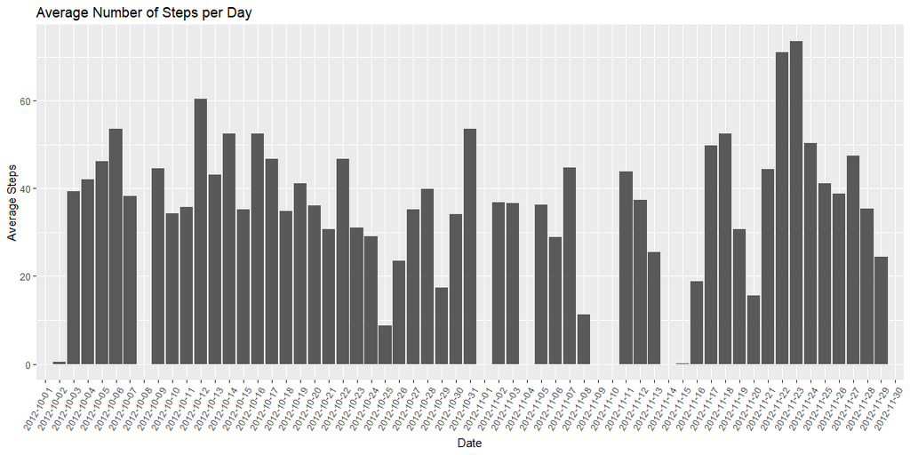

```r
library(ggplot2)
meanplot<-ggplot(data,aes(x=factor(date),y=steps))+ stat_summary(fun.y="mean", geom="bar")
meanplot + xlab("Date")+ylab("Average Steps")+ggtitle("Average Number of Steps per Day") + theme(axis.text.x=element_text(angle=60, hjust=1))
```

For this, I will also use the aggregate function. First, the mean:

```r
ave<-aggregate(steps~date, data=data, rm.na=TRUE, FUN=mean)
print(xtable(ave), type = "html")
```

|  | date | steps |
| --- | --- | --- |
| 1 | 2012-10-02 | 0.44 |
| 2 | 2012-10-03 | 39.42 |
| 3 | 2012-10-04 | 42.07 |
| 4 | 2012-10-05 | 46.16 |
| 5 | 2012-10-06 | 53.54 |
| 6 | 2012-10-07 | 38.25 |
| 7 | 2012-10-09 | 44.48 |
| 8 | 2012-10-10 | 34.38 |
| 9 | 2012-10-11 | 35.78 |
| 10 | 2012-10-12 | 60.35 |
| 11 | 2012-10-13 | 43.15 |
| 12 | 2012-10-14 | 52.42 |
| 13 | 2012-10-15 | 35.20 |
| 14 | 2012-10-16 | 52.38 |
| 15 | 2012-10-17 | 46.71 |
| 16 | 2012-10-18 | 34.92 |
| 17 | 2012-10-19 | 41.07 |
| 18 | 2012-10-20 | 36.09 |
| 19 | 2012-10-21 | 30.63 |
| 20 | 2012-10-22 | 46.74 |
| 21 | 2012-10-23 | 30.97 |
| 22 | 2012-10-24 | 29.01 |
| 23 | 2012-10-25 | 8.65 |
| 24 | 2012-10-26 | 23.53 |
| 25 | 2012-10-27 | 35.14 |
| 26 | 2012-10-28 | 39.78 |
| 27 | 2012-10-29 | 17.42 |
| 28 | 2012-10-30 | 34.09 |
| 29 | 2012-10-31 | 53.52 |
| 30 | 2012-11-02 | 36.81 |
| 31 | 2012-11-03 | 36.70 |
| 32 | 2012-11-05 | 36.25 |
| 33 | 2012-11-06 | 28.94 |
| 34 | 2012-11-07 | 44.73 |
| 35 | 2012-11-08 | 11.18 |
| 36 | 2012-11-11 | 43.78 |
| 37 | 2012-11-12 | 37.38 |
| 38 | 2012-11-13 | 25.47 |
| 39 | 2012-11-15 | 0.14 |
| 40 | 2012-11-16 | 18.89 |
| 41 | 2012-11-17 | 49.79 |
| 42 | 2012-11-18 | 52.47 |
| 43 | 2012-11-19 | 30.70 |
| 44 | 2012-11-20 | 15.53 |
| 45 | 2012-11-21 | 44.40 |
| 46 | 2012-11-22 | 70.93 |
| 47 | 2012-11-23 | 73.59 |
| 48 | 2012-11-24 | 50.27 |
| 49 | 2012-11-25 | 41.09 |
| 50 | 2012-11-26 | 38.76 |
| 51 | 2012-11-27 | 47.38 |
| 52 | 2012-11-28 | 35.36 |
| 53 | 2012-11-29 | 24.47 |

Next, the median:

```r
medi<-aggregate(steps~date, data=data, rm.na=TRUE, FUN=median)
print(xtable(medi), type = "html")
```

|  | date | steps |
| --- | --- | --- |
| 1 | 2012-10-02 | 0.00 |
| 2 | 2012-10-03 | 0.00 |
| 3 | 2012-10-04 | 0.00 |
| 4 | 2012-10-05 | 0.00 |
| 5 | 2012-10-06 | 0.00 |
| 6 | 2012-10-07 | 0.00 |
| 7 | 2012-10-09 | 0.00 |
| 8 | 2012-10-10 | 0.00 |
| 9 | 2012-10-11 | 0.00 |
| 10 | 2012-10-12 | 0.00 |
| 11 | 2012-10-13 | 0.00 |
| 12 | 2012-10-14 | 0.00 |
| 13 | 2012-10-15 | 0.00 |
| 14 | 2012-10-16 | 0.00 |
| 15 | 2012-10-17 | 0.00 |
| 16 | 2012-10-18 | 0.00 |
| 17 | 2012-10-19 | 0.00 |
| 18 | 2012-10-20 | 0.00 |
| 19 | 2012-10-21 | 0.00 |
| 20 | 2012-10-22 | 0.00 |
| 21 | 2012-10-23 | 0.00 |
| 22 | 2012-10-24 | 0.00 |
| 23 | 2012-10-25 | 0.00 |
| 24 | 2012-10-26 | 0.00 |
| 25 | 2012-10-27 | 0.00 |
| 26 | 2012-10-28 | 0.00 |
| 27 | 2012-10-29 | 0.00 |
| 28 | 2012-10-30 | 0.00 |
| 29 | 2012-10-31 | 0.00 |
| 30 | 2012-11-02 | 0.00 |
| 31 | 2012-11-03 | 0.00 |
| 32 | 2012-11-05 | 0.00 |
| 33 | 2012-11-06 | 0.00 |
| 34 | 2012-11-07 | 0.00 |
| 35 | 2012-11-08 | 0.00 |
| 36 | 2012-11-11 | 0.00 |
| 37 | 2012-11-12 | 0.00 |
| 38 | 2012-11-13 | 0.00 |
| 39 | 2012-11-15 | 0.00 |
| 40 | 2012-11-16 | 0.00 |
| 41 | 2012-11-17 | 0.00 |
| 42 | 2012-11-18 | 0.00 |
| 43 | 2012-11-19 | 0.00 |
| 44 | 2012-11-20 | 0.00 |
| 45 | 2012-11-21 | 0.00 |
| 46 | 2012-11-22 | 0.00 |
| 47 | 2012-11-23 | 0.00 |
| 48 | 2012-11-24 | 0.00 |
| 49 | 2012-11-25 | 0.00 |
| 50 | 2012-11-26 | 0.00 |
| 51 | 2012-11-27 | 0.00 |
| 52 | 2012-11-28 | 0.00 |
| 53 | 2012-11-29 | 0.00 |

## What is the average daily activity pattern?

### Make a time series plot of the time intervals.

For this, I will use the base plotting system.

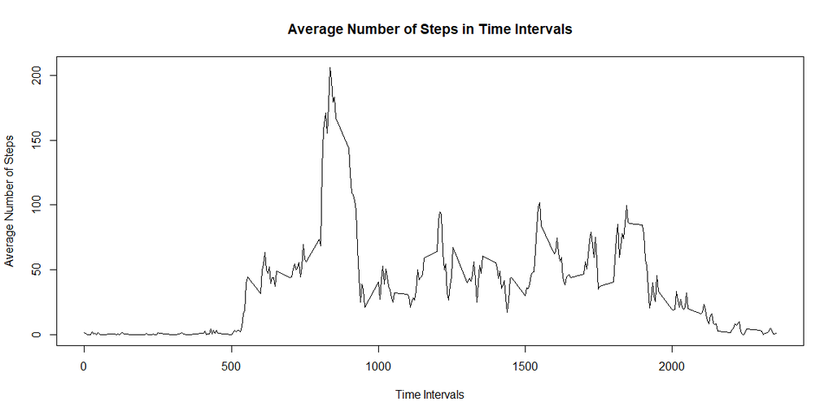

```r
inter<-aggregate(steps~interval,data=data,rm.na=TRUE,FUN=mean)
plot(inter,type="l",xlab="Time Intervals",ylab="Average Number of Steps",main="Average Number of Steps in Time Intervals")
```

### Which 5-minute interval contains the maximum number of steps?

Since we already have a data frame of the aggregated average steps with time intervals (“inter”), I will simply get the max from that.

```r
sortinter<-inter[order(-inter$steps),]
sortinter[1,]
```

```
##     interval    steps
## 104      835 206.1698
```

## Imputing missing values

### Counting the number of NA rows

For this, I will use the is.na function, with colSums so we know which columns have the corresponding number of NAs.

```r
colSums(is.na(data))
```

```
##    steps     date interval
##     2304        0        0
```

### Filling in the NA rows

I used the na.omit function:

```r
newdata<-data
newdata$steps[is.na(newdata$steps)]<-mean(na.omit(data$steps))
```

### Looking at the difference

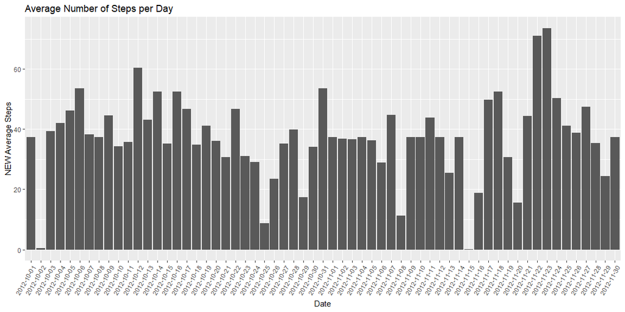

```r
newmeans<-ggplot(newdata,aes(x=factor(date),y=steps))+ stat_summary(fun.y="mean", geom="bar")
newmeans + xlab("Date")+ylab("NEW Average Steps")+ggtitle("Average Number of Steps per Day") + theme(axis.text.x=element_text(angle=60, hjust=1))
```

NEW means:

```r
newave<-aggregate(steps~date, data=newdata, rm.na=TRUE, FUN=mean)
print(xtable(newave), type = "html")
```

|  | date | steps |
| --- | --- | --- |
| 1 | 2012-10-01 | 37.38 |
| 2 | 2012-10-02 | 0.44 |
| 3 | 2012-10-03 | 39.42 |
| 4 | 2012-10-04 | 42.07 |
| 5 | 2012-10-05 | 46.16 |
| 6 | 2012-10-06 | 53.54 |
| 7 | 2012-10-07 | 38.25 |
| 8 | 2012-10-08 | 37.38 |
| 9 | 2012-10-09 | 44.48 |
| 10 | 2012-10-10 | 34.38 |
| 11 | 2012-10-11 | 35.78 |
| 12 | 2012-10-12 | 60.35 |
| 13 | 2012-10-13 | 43.15 |
| 14 | 2012-10-14 | 52.42 |
| 15 | 2012-10-15 | 35.20 |
| 16 | 2012-10-16 | 52.38 |
| 17 | 2012-10-17 | 46.71 |
| 18 | 2012-10-18 | 34.92 |
| 19 | 2012-10-19 | 41.07 |
| 20 | 2012-10-20 | 36.09 |
| 21 | 2012-10-21 | 30.63 |
| 22 | 2012-10-22 | 46.74 |
| 23 | 2012-10-23 | 30.97 |
| 24 | 2012-10-24 | 29.01 |
| 25 | 2012-10-25 | 8.65 |
| 26 | 2012-10-26 | 23.53 |
| 27 | 2012-10-27 | 35.14 |
| 28 | 2012-10-28 | 39.78 |
| 29 | 2012-10-29 | 17.42 |
| 30 | 2012-10-30 | 34.09 |
| 31 | 2012-10-31 | 53.52 |
| 32 | 2012-11-01 | 37.38 |
| 33 | 2012-11-02 | 36.81 |
| 34 | 2012-11-03 | 36.70 |
| 35 | 2012-11-04 | 37.38 |
| 36 | 2012-11-05 | 36.25 |
| 37 | 2012-11-06 | 28.94 |
| 38 | 2012-11-07 | 44.73 |
| 39 | 2012-11-08 | 11.18 |
| 40 | 2012-11-09 | 37.38 |
| 41 | 2012-11-10 | 37.38 |
| 42 | 2012-11-11 | 43.78 |
| 43 | 2012-11-12 | 37.38 |
| 44 | 2012-11-13 | 25.47 |
| 45 | 2012-11-14 | 37.38 |
| 46 | 2012-11-15 | 0.14 |
| 47 | 2012-11-16 | 18.89 |
| 48 | 2012-11-17 | 49.79 |
| 49 | 2012-11-18 | 52.47 |
| 50 | 2012-11-19 | 30.70 |
| 51 | 2012-11-20 | 15.53 |
| 52 | 2012-11-21 | 44.40 |
| 53 | 2012-11-22 | 70.93 |
| 54 | 2012-11-23 | 73.59 |
| 55 | 2012-11-24 | 50.27 |
| 56 | 2012-11-25 | 41.09 |
| 57 | 2012-11-26 | 38.76 |
| 58 | 2012-11-27 | 47.38 |
| 59 | 2012-11-28 | 35.36 |
| 60 | 2012-11-29 | 24.47 |
| 61 | 2012-11-30 | 37.38 |

NEW medians:

```r
newmedi<-aggregate(steps~date, data=newdata, rm.na=TRUE, FUN=median)
print(xtable(newmedi), type = "html")
```

|  | date | steps |
| --- | --- | --- |
| 1 | 2012-10-01 | 37.38 |
| 2 | 2012-10-02 | 0.00 |
| 3 | 2012-10-03 | 0.00 |
| 4 | 2012-10-04 | 0.00 |
| 5 | 2012-10-05 | 0.00 |
| 6 | 2012-10-06 | 0.00 |
| 7 | 2012-10-07 | 0.00 |
| 8 | 2012-10-08 | 37.38 |
| 9 | 2012-10-09 | 0.00 |
| 10 | 2012-10-10 | 0.00 |
| 11 | 2012-10-11 | 0.00 |
| 12 | 2012-10-12 | 0.00 |
| 13 | 2012-10-13 | 0.00 |
| 14 | 2012-10-14 | 0.00 |
| 15 | 2012-10-15 | 0.00 |
| 16 | 2012-10-16 | 0.00 |
| 17 | 2012-10-17 | 0.00 |
| 18 | 2012-10-18 | 0.00 |
| 19 | 2012-10-19 | 0.00 |
| 20 | 2012-10-20 | 0.00 |
| 21 | 2012-10-21 | 0.00 |
| 22 | 2012-10-22 | 0.00 |
| 23 | 2012-10-23 | 0.00 |
| 24 | 2012-10-24 | 0.00 |
| 25 | 2012-10-25 | 0.00 |
| 26 | 2012-10-26 | 0.00 |
| 27 | 2012-10-27 | 0.00 |
| 28 | 2012-10-28 | 0.00 |
| 29 | 2012-10-29 | 0.00 |
| 30 | 2012-10-30 | 0.00 |
| 31 | 2012-10-31 | 0.00 |
| 32 | 2012-11-01 | 37.38 |
| 33 | 2012-11-02 | 0.00 |
| 34 | 2012-11-03 | 0.00 |
| 35 | 2012-11-04 | 37.38 |
| 36 | 2012-11-05 | 0.00 |
| 37 | 2012-11-06 | 0.00 |
| 38 | 2012-11-07 | 0.00 |
| 39 | 2012-11-08 | 0.00 |
| 40 | 2012-11-09 | 37.38 |
| 41 | 2012-11-10 | 37.38 |
| 42 | 2012-11-11 | 0.00 |
| 43 | 2012-11-12 | 0.00 |
| 44 | 2012-11-13 | 0.00 |
| 45 | 2012-11-14 | 37.38 |
| 46 | 2012-11-15 | 0.00 |
| 47 | 2012-11-16 | 0.00 |
| 48 | 2012-11-17 | 0.00 |
| 49 | 2012-11-18 | 0.00 |
| 50 | 2012-11-19 | 0.00 |
| 51 | 2012-11-20 | 0.00 |
| 52 | 2012-11-21 | 0.00 |
| 53 | 2012-11-22 | 0.00 |
| 54 | 2012-11-23 | 0.00 |
| 55 | 2012-11-24 | 0.00 |
| 56 | 2012-11-25 | 0.00 |
| 57 | 2012-11-26 | 0.00 |
| 58 | 2012-11-27 | 0.00 |
| 59 | 2012-11-28 | 0.00 |
| 60 | 2012-11-29 | 0.00 |
| 61 | 2012-11-30 | 37.38 |

When comparing these results, there IS a difference, but only a slight one in a few days (like the first day, for example).

## Are there differences in activity patterns between weekdays and weekends?

### Adding a variable indicating whether the date is a weekend or a weekday (in column “wDay”)

```r
newdata$date <- as.Date(newdata$date)
weekdays1 <- c('Monday', 'Tuesday', 'Wednesday', 'Thursday', 'Friday')
newdata$wDay <- factor((weekdays(newdata$date) %in% weekdays1),
         levels=c(FALSE, TRUE), labels=c('weekend', 'weekday'))
```

Look at the new data here:

```r
newdata$date <- data$date
print(xtable(head(newdata)),type="html")
```

|  | steps | date | interval | wDay |
| --- | --- | --- | --- | --- |
| 1 | 37.38 | 2012-10-01 | 0 | weekday |
| 2 | 37.38 | 2012-10-01 | 5 | weekday |
| 3 | 37.38 | 2012-10-01 | 10 | weekday |
| 4 | 37.38 | 2012-10-01 | 15 | weekday |
| 5 | 37.38 | 2012-10-01 | 20 | weekday |
| 6 | 37.38 | 2012-10-01 | 25 | weekday |

### Comparing the plots of weekday and weekend based on time intervals

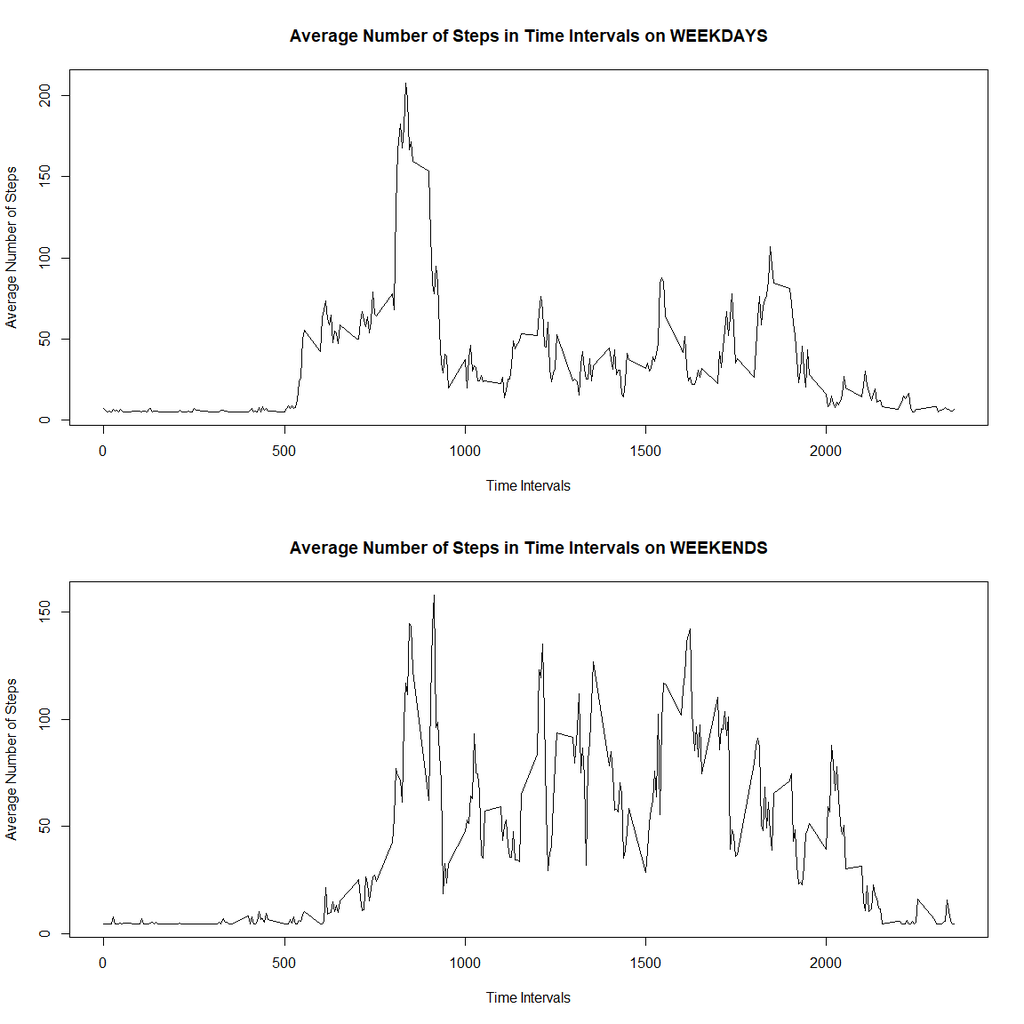

```r
daydata<-newdata[newdata$wDay=="weekday",]
enddata<-newdata[newdata$wDay=="weekend",]

par(mfrow = c(2, 1))
dayplot<-aggregate(steps~interval,data=daydata,rm.na=TRUE,FUN=mean)
endplot<-aggregate(steps~interval,data=enddata,rm.na=TRUE,FUN=mean)
plot(dayplot,type="l",xlab="Time Intervals",ylab="Average Number of Steps",main="Average Number of Steps in Time Intervals on WEEKDAYS")
plot(endplot,type="l",xlab="Time Intervals",ylab="Average Number of Steps",main="Average Number of Steps in Time Intervals on WEEKENDS")
```